# Association Analysis

## STAT318/462 Lab6:

### Association Analysis using the Apriori algorithm

There is no lab section for association analysis in the course textbook, An Introduction to Statistical Learning (there is a link to this textbook on the Learn page).

The first thing to do is to load the necessary package

```r
library(arules)
```

convert the .csv data to a list of transactions

```r
data = read.transactions(file="Basket1.txt",format="basket",sep=",")
inspect(data)
```

```
##     items
## [1] {Bread,Milk}
## [2] {Beer,Bread,Diapers,Eggs}
## [3] {Beer,Cola,Diapers,Milk}
## [4] {Beer,Bread,Diapers,Milk}
## [5] {Bread,Cola,Diapers,Milk}
```

mine the frequent itemsets, view all the frequent itemsets, view the five frequent itemsets with the greatest support

```r
FreqItemsets <- apriori(data,parameter=list(support=0.4,target="frequent itemsets"))
```

```
## Apriori
##
## Parameter specification:
##  confidence minval smax arem  aval originalSupport maxtime support minlen
##          NA    0.1    1 none FALSE            TRUE       5     0.4      1
##  maxlen            target   ext
##      10 frequent itemsets FALSE
##
## Algorithmic control:
##  filter tree heap memopt load sort verbose
##     0.1 TRUE TRUE  FALSE TRUE    2    TRUE
##
## Absolute minimum support count: 2
##
## set item appearances ...[0 item(s)] done [0.00s].
## set transactions ...[6 item(s), 5 transaction(s)] done [0.00s].
## sorting and recoding items ... [5 item(s)] done [0.00s].
## creating transaction tree ... done [0.00s].
## checking subsets of size 1 2 3 done [0.00s].
## writing ... [17 set(s)] done [0.00s].
## creating S4 object  ... done [0.00s].
```

```r
inspect(FreqItemsets)
```

```
##      items                support count
## [1]  {Cola}               0.4     2
## [2]  {Beer}               0.6     3
## [3]  {Milk}               0.8     4
## [4]  {Bread}              0.8     4
## [5]  {Diapers}            0.8     4
## [6]  {Cola,Milk}          0.4     2
## [7]  {Cola,Diapers}       0.4     2
## [8]  {Beer,Milk}          0.4     2
## [9]  {Beer,Bread}         0.4     2
## [10] {Beer,Diapers}       0.6     3
## [11] {Bread,Milk}         0.6     3
## [12] {Diapers,Milk}       0.6     3
## [13] {Bread,Diapers}      0.6     3
## [14] {Cola,Diapers,Milk}  0.4     2
## [15] {Beer,Diapers,Milk}  0.4     2
## [16] {Beer,Bread,Diapers} 0.4     2
## [17] {Bread,Diapers,Milk} 0.4     2
```

```r
inspect(sort(FreqItemsets, by="support")[1:5])
```

```
##     items          support count
## [1] {Milk}         0.8     4
## [2] {Bread}        0.8     4
## [3] {Diapers}      0.8     4
## [4] {Beer}         0.6     3
## [5] {Beer,Diapers} 0.6     3
```

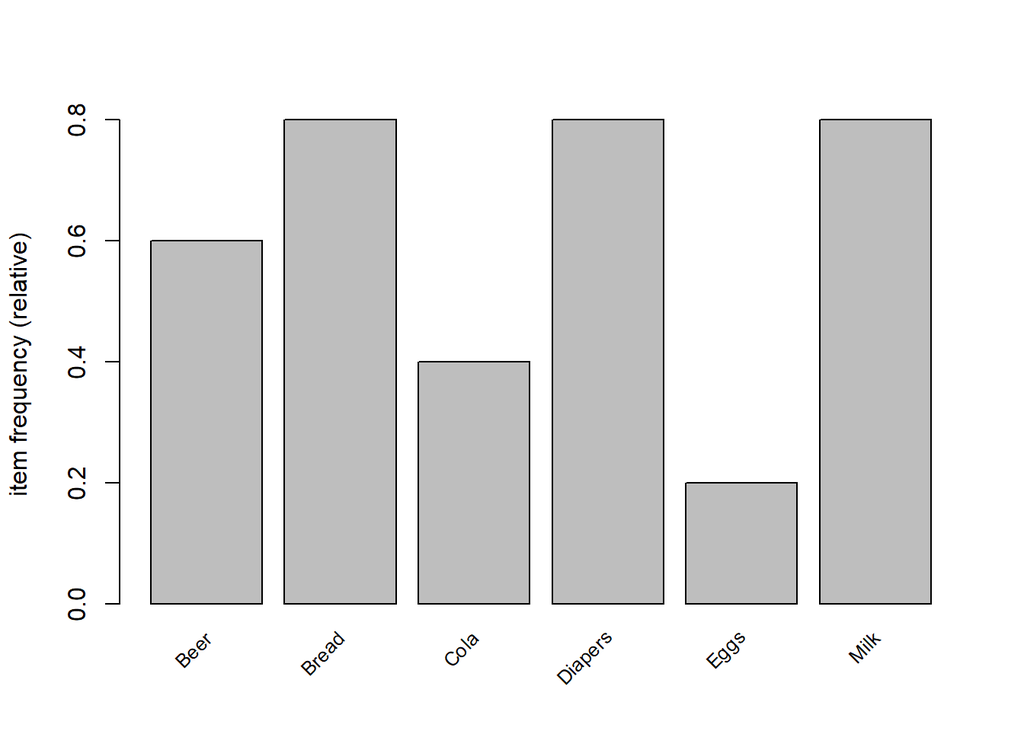

```r
itemFrequencyPlot(data, support = 0.1, cex.names=0.8)
```

mine the maximal frequent itemsets, view all the frequent itemsets

```r
MaxFreqItemsets <- apriori(data,parameter=list(support=0.3,target="maximally frequent itemsets"))
```

```
## Apriori
##
## Parameter specification:
##  confidence minval smax arem  aval originalSupport maxtime support minlen
##          NA    0.1    1 none FALSE            TRUE       5     0.3      1
##  maxlen                      target   ext
##      10 maximally frequent itemsets FALSE
##
## Algorithmic control:
##  filter tree heap memopt load sort verbose
##     0.1 TRUE TRUE  FALSE TRUE    2    TRUE
##
## Absolute minimum support count: 1
##
## set item appearances ...[0 item(s)] done [0.00s].
## set transactions ...[6 item(s), 5 transaction(s)] done [0.00s].
## sorting and recoding items ... [5 item(s)] done [0.00s].
## creating transaction tree ... done [0.00s].
## checking subsets of size 1 2 3 done [0.00s].
## filtering maximal item sets ... done [0.00s].
## writing ... [4 set(s)] done [0.00s].
## creating S4 object  ... done [0.00s].
```

```r
inspect(MaxFreqItemsets)
```

```
##     items                support count
## [1] {Cola,Diapers,Milk}  0.4     2
## [2] {Beer,Diapers,Milk}  0.4     2
## [3] {Beer,Bread,Diapers} 0.4     2
## [4] {Bread,Diapers,Milk} 0.4     2
```

```r
summary(MaxFreqItemsets)
```

```
## set of 4 itemsets
##
## most frequent items:
## Diapers    Milk    Beer   Bread    Cola (Other)
##       4       3       2       2       1       0
##
## element (itemset/transaction) length distribution:sizes
## 3
## 4
##
##    Min. 1st Qu.  Median    Mean 3rd Qu.    Max.
##       3       3       3       3       3       3
##
## summary of quality measures:
##     support        count
##  Min.   :0.4   Min.   :2
##  1st Qu.:0.4   1st Qu.:2
##  Median :0.4   Median :2
##  Mean   :0.4   Mean   :2
##  3rd Qu.:0.4   3rd Qu.:2
##  Max.   :0.4   Max.   :2
##
## includes transaction ID lists: FALSE
##
## mining info:
##  data ntransactions support confidence
##  data             5     0.3          1
```

mine the closed frequent itemsets, view all the frequent itemsets

```r
ClosedFreqItemsets <- apriori(data,parameter=list(support=0.4,target="closed frequent itemsets"))
```

```
## Apriori
##
## Parameter specification:
##  confidence minval smax arem  aval originalSupport maxtime support minlen
##          NA    0.1    1 none FALSE            TRUE       5     0.4      1
##  maxlen                   target   ext
##      10 closed frequent itemsets FALSE
##
## Algorithmic control:
##  filter tree heap memopt load sort verbose
##     0.1 TRUE TRUE  FALSE TRUE    2    TRUE
##
## Absolute minimum support count: 2
##
## set item appearances ...[0 item(s)] done [0.00s].
## set transactions ...[6 item(s), 5 transaction(s)] done [0.00s].
## sorting and recoding items ... [5 item(s)] done [0.00s].
## creating transaction tree ... done [0.00s].
## checking subsets of size 1 2 3 done [0.00s].
## filtering closed item sets ... done [0.00s].
## writing ... [11 set(s)] done [0.00s].
## creating S4 object  ... done [0.00s].
```

```r
summary(ClosedFreqItemsets)
```

```
## set of 11 itemsets
##
## most frequent items:
## Diapers    Milk   Bread    Beer    Cola (Other)
##       8       6       5       3       1       0
##
## element (itemset/transaction) length distribution:sizes
## 1 2 3
## 3 4 4
##
##    Min. 1st Qu.  Median    Mean 3rd Qu.    Max.
##   1.000   1.500   2.000   2.091   3.000   3.000
##
## summary of quality measures:
##     support           count
##  Min.   :0.4000   Min.   :2.000
##  1st Qu.:0.4000   1st Qu.:2.000
##  Median :0.6000   Median :3.000
##  Mean   :0.5818   Mean   :2.909
##  3rd Qu.:0.7000   3rd Qu.:3.500
##  Max.   :0.8000   Max.   :4.000
##
## includes transaction ID lists: FALSE
##
## mining info:
##  data ntransactions support confidence
##  data             5     0.4          1
```

mine the association rules, view all the rules, and view the five rules with highest confidence

```r
rules <- apriori(data,parameter=list(minlen=2,support=0.4,confidence=0.8,target="rules"))
```

```
## Apriori
##
## Parameter specification:
##  confidence minval smax arem  aval originalSupport maxtime support minlen
##         0.8    0.1    1 none FALSE            TRUE       5     0.4      2
##  maxlen target   ext
##      10  rules FALSE
##
## Algorithmic control:
##  filter tree heap memopt load sort verbose
##     0.1 TRUE TRUE  FALSE TRUE    2    TRUE
##
## Absolute minimum support count: 2
##
## set item appearances ...[0 item(s)] done [0.00s].
## set transactions ...[6 item(s), 5 transaction(s)] done [0.00s].
## sorting and recoding items ... [5 item(s)] done [0.00s].
## creating transaction tree ... done [0.00s].
## checking subsets of size 1 2 3 done [0.00s].
## writing ... [7 rule(s)] done [0.00s].
## creating S4 object  ... done [0.00s].
```

```r
inspect(rules)
```

```
##     lhs               rhs       support confidence lift count
## [1] {Cola}         => {Milk}    0.4     1          1.25 2
## [2] {Cola}         => {Diapers} 0.4     1          1.25 2
## [3] {Beer}         => {Diapers} 0.6     1          1.25 3
## [4] {Cola,Milk}    => {Diapers} 0.4     1          1.25 2
## [5] {Cola,Diapers} => {Milk}    0.4     1          1.25 2
## [6] {Beer,Milk}    => {Diapers} 0.4     1          1.25 2
## [7] {Beer,Bread}   => {Diapers} 0.4     1          1.25 2
```

```r
summary(rules)
```

```
## set of 7 rules
##
## rule length distribution (lhs + rhs):sizes
## 2 3
## 3 4
##
##    Min. 1st Qu.  Median    Mean 3rd Qu.    Max.
##   2.000   2.000   3.000   2.571   3.000   3.000
##
## summary of quality measures:
##     support         confidence      lift          count
##  Min.   :0.4000   Min.   :1    Min.   :1.25   Min.   :2.000
##  1st Qu.:0.4000   1st Qu.:1    1st Qu.:1.25   1st Qu.:2.000
##  Median :0.4000   Median :1    Median :1.25   Median :2.000
##  Mean   :0.4286   Mean   :1    Mean   :1.25   Mean   :2.143
##  3rd Qu.:0.4000   3rd Qu.:1    3rd Qu.:1.25   3rd Qu.:2.000
##  Max.   :0.6000   Max.   :1    Max.   :1.25   Max.   :3.000
##
## mining info:
##  data ntransactions support confidence
##  data             5     0.4        0.8
```

```r
inspect(sort(rules, by="confidence")[1:5])
```

```
##     lhs               rhs       support confidence lift count
## [1] {Cola}         => {Milk}    0.4     1          1.25 2
## [2] {Cola}         => {Diapers} 0.4     1          1.25 2
## [3] {Beer}         => {Diapers} 0.6     1          1.25 3
## [4] {Cola,Milk}    => {Diapers} 0.4     1          1.25 2
## [5] {Cola,Diapers} => {Milk}    0.4     1          1.25 2
```

find particular rules

```r
rules <- apriori(data,parameter=list(minlen=2,support=0.4,confidence=0.8,target="rules"),appearance=list(default="lhs",rhs="Milk"))
```

```
## Apriori
##
## Parameter specification:
##  confidence minval smax arem  aval originalSupport maxtime support minlen
##         0.8    0.1    1 none FALSE            TRUE       5     0.4      2
##  maxlen target   ext
##      10  rules FALSE
##
## Algorithmic control:
##  filter tree heap memopt load sort verbose
##     0.1 TRUE TRUE  FALSE TRUE    2    TRUE
##
## Absolute minimum support count: 2
##
## set item appearances ...[1 item(s)] done [0.00s].
## set transactions ...[6 item(s), 5 transaction(s)] done [0.00s].
## sorting and recoding items ... [5 item(s)] done [0.00s].
## creating transaction tree ... done [0.00s].
## checking subsets of size 1 2 3 done [0.00s].
## writing ... [2 rule(s)] done [0.00s].
## creating S4 object  ... done [0.00s].
```

```r
summary(rules)
```

```
## set of 2 rules
##
## rule length distribution (lhs + rhs):sizes
## 2 3
## 1 1
##
##    Min. 1st Qu.  Median    Mean 3rd Qu.    Max.
##    2.00    2.25    2.50    2.50    2.75    3.00
##
## summary of quality measures:
##     support      confidence      lift          count
##  Min.   :0.4   Min.   :1    Min.   :1.25   Min.   :2
##  1st Qu.:0.4   1st Qu.:1    1st Qu.:1.25   1st Qu.:2
##  Median :0.4   Median :1    Median :1.25   Median :2
##  Mean   :0.4   Mean   :1    Mean   :1.25   Mean   :2
##  3rd Qu.:0.4   3rd Qu.:1    3rd Qu.:1.25   3rd Qu.:2
##  Max.   :0.4   Max.   :1    Max.   :1.25   Max.   :2
##
## mining info:
##  data ntransactions support confidence
##  data             5     0.4        0.8
```

```r
inspect(sort(rules, by="confidence"))
```

```
##     lhs               rhs    support confidence lift count
## [1] {Cola}         => {Milk} 0.4     1          1.25 2
## [2] {Cola,Diapers} => {Milk} 0.4     1          1.25 2
```

Use ?apriori, then click on ‘APappearance’ to see how to extract more complicated rules

## Other data sets to play with for association analysis:

Adult Census Income Database

```r
data("Adult")
Adult
```

```
## transactions in sparse format with
##  48842 transactions (rows) and
##  115 items (columns)
```

Groceries data set contains 1 month (30 days) of real-world point-of-sale transaction data

```r
data("Groceries")
Groceries
```

```
## transactions in sparse format with
##  9835 transactions (rows) and
##  169 items (columns)
```

Use ?apriori, then click on ‘APappearance’ to see how to extract more complicated rules

**RealTransactionData_NovDec_2019.xlsx**, data set contains 2 months of real-world point-of-sale transaction data. Please see the ReadMe file for data coloumn info. You need Transaction ID to match the transcations, and Product Code to match the product. Some data cleaning is needed! This is a real dataset I obtained from my industry contact, so it is for learning and research work at UC only.

Not testable, just an interesting example.

I have cleaned the Nov 2019 data into **RealTransactionData_Nov_2019.csv**, with two columns: “Transaction ID”,“Product Code”. Here is how to load in the transaction data.

```r
# Read that csv back in
order_Nov19_trans <- read.transactions(
        file = "RealTransactionData_Nov_2019.csv",
        format = "single",
        sep = ",",
        cols=c("Transaction ID","Product Code"),
        rm.duplicates = T,
        header = T
)
summary(order_Nov19_trans)
```

```
## transactions as itemMatrix in sparse format with
##  37135 rows (elements/itemsets/transactions) and
##  11840 columns (items) and a density of 0.0003876993
##
## most frequent items:
##  141970  288888  126713  144034   20484 (Other)
##    1780    1426    1189    1096    1076  163896
##
## element (itemset/transaction) length distribution:
## sizes
##     1     2     3     4     5     6     7     8     9    10    11    12    13
## 11708  6271  4177  2981  2187  1696  1353  1136   898   780   652   535   482
##    14    15    16    17    18    19    20    21    22    23    24    25    26
##   341   275   250   207   184   131   117   105   102    73    53    48    53
##    27    28    29    30    31    32    33    34    35    36    37    38    39
##    28    35    30    33    28    26    22    13    20    11     5     6     8
##    40    41    42    43    44    45    46    47    48    49    50    51    52
##    12    11     6     8     4     4     6     1     2     3     3     2     1
##    55    56    57    61    64    65    70    71    89
##     1     1     3     1     1     1     1     2     1
##
##    Min. 1st Qu.  Median    Mean 3rd Qu.    Max.
##    1.00    1.00    3.00    4.59    6.00   89.00
##
## includes extended item information - examples:
##   labels
## 1
## 2 100006
## 3 100011
##
## includes extended transaction information - examples:
##   transactionID
## 1
## 2   10001191101
## 3   10001191102
```

Finding frequent itemsets, with 2% occurance or more:

```r
FreqItemsets <- apriori(order_Nov19_trans,parameter=list(support=0.02,target="frequent itemsets"))
```

```
## Apriori
##
## Parameter specification:
##  confidence minval smax arem  aval originalSupport maxtime support minlen
##          NA    0.1    1 none FALSE            TRUE       5    0.02      1
##  maxlen            target   ext
##      10 frequent itemsets FALSE
##
## Algorithmic control:
##  filter tree heap memopt load sort verbose
##     0.1 TRUE TRUE  FALSE TRUE    2    TRUE
##
## Absolute minimum support count: 742
##
## set item appearances ...[0 item(s)] done [0.00s].
## set transactions ...[11840 item(s), 37135 transaction(s)] done [0.16s].
## sorting and recoding items ... [10 item(s)] done [0.00s].
## creating transaction tree ... done [0.00s].
## checking subsets of size 1 2 done [0.00s].
## writing ... [10 set(s)] done [0.00s].
## creating S4 object  ... done [0.00s].
```

```r
inspect(FreqItemsets)
```

```
##      items     support    count
## [1]  {220909}  0.02154302  800
## [2]  {20484}   0.02897536 1076
## [3]  {1007093} 0.02760199 1025
## [4]  {147297}  0.02819443 1047
## [5]  {145335}  0.02423590  900
## [6]  {128167}  0.02709035 1006
## [7]  {126713}  0.03201831 1189
## [8]  {144034}  0.02951394 1096
## [9]  {141970}  0.04793322 1780
## [10] {288888}  0.03840043 1426
```

Write your code here (to find frequent 2 and 3 itemsets), and the association rules.

Repeat this for the Dec data, you would have to do the data cleaning yourself.

Then report this back in terms of Product Name rather than Product Code. ***